# Short-Term Demand Evolution of Videos and Streamers on Twitch

Computer Systems and Performance Evaluation

Amirabbs Jalali - amj301

### Introduction.

Nowadays, lots of content are going to be streamed online, and they can be reached simply by web browsers on any device. Twitch was the first platform that exclusively designed for live streaming video games from every game device. For instance, game consoles, mobile phones, etc. In this paper, I aim to find the evolution of the most popular trends in games and how the number of followers for streamers grows in this platform. At last, I want to statistically test some hypotheses about this system to find a better understanding of user behaviour and how to help this system to adapt to these trends.

### The Datasets.

In this section, I will talk about the datasets that I used in this paper. First, I used one day period for finding trends and overview. After that, I used 2 weeks periods to find out the difference when it comes to a more extended period. The 2 weeks dataset is available on “https://clivecast.github.io/”. The original dataset covers a month with 5 minutes sample rate, but it is a huge dataset. To make that computational feasible, I only use 2 weeks with a 1-hour sampling rate. One day period dataset is available on “https://github.com/Codecademy/datasets/tree/master/twitch” and gathered by Codecademy and Twitch Science Team. The 2 weeks dataset is not completely clean, especially in the game name column there are lots of inconsistencies, for example, some games present in the dataset with full name and their abbreviation name. Consequently, I have to found those games and eliminate this issue. It is impossible to do this for all of the games, but it can be achieved for the most popular games. I check these games and manually remove those inconsistencies. For other games, I try to give them a specific format; I change all characters to lower case and then remove all the punctuations to increase game names consistency.

```r
library(readr)
library(data.table)
library(dplyr)

files = list.files(path="Dataset/Twitch_data/", pattern="*00-00.txt")

setwd("/Users/AJ/Downloads/Computer Systems and Performance Evaluation/Final Project/Dataset/Twitch_data/")

datalist = lapply(files, read.delim)

datalist = datalist %>% rbindlist(., fill=F)

colnames(datalist) = c('stream_id',
                       'current_views',
                       'created_time',
                       'game',
                       'broadcaster_id',
                       'broadcaster_name',
                       'delay',
                       'followers_number',
                       'partner_status',
                       'language',
                       'total_views',
                       'web_language',
                       'broadcaster_created_time',
                       'bitrate',
                       'resolution',
                       'NA')

datalist = datalist %>% select('stream_id',
                       'current_views',
                       'created_time',
                       'game',
                       'broadcaster_id',
                       'broadcaster_name',
                       'delay',
                       'followers_number',
                       'partner_status',
                       'language',
                       'total_views',
                       'web_language',
                       'broadcaster_created_time',
                       'bitrate',
                       'resolution')

setwd("/Users/AJ/Downloads/Computer Systems and Performance Evaluation/Final Project/")

chats = read_csv("data/chat.csv", col_names = c("time","device_id","login",
                                                "channel","country","player",
                                                "game"))
streams = read_csv("data/stream.csv")
```

### Experiments.

In this section, I will answer some questions about demand evolution in Twitch.

#### One day demand evolution of most popular games

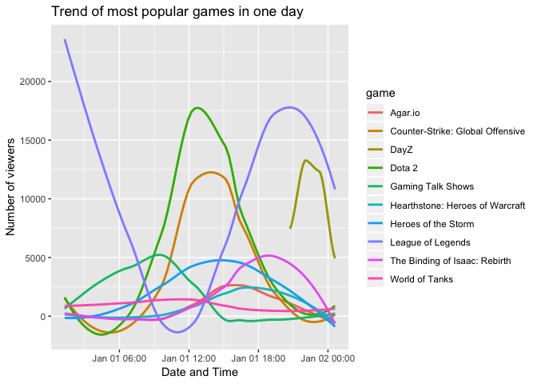

```r
library(lubridate)
library(dplyr)
library(highcharter)
library(ggplot2)

stream_evo = streams %>%
  select('time','game') %>%
  mutate(time = as.numeric(as.POSIXct(time))) %>%
  mutate(cuts = cut(time, c(1420070200,
                            1420075346,
                            1420080293,
                            1420085239,
                            1420090186,
                            1420095132,
                            1420100079,
                            1420105025,
                            1420109972,
                            1420114918,
                            1420119865,
                            1420124811,
                            1420129758,
                            1420134704,
                            1420139651,
                            1420144597,
                            1420149544,
                            1420154490,
                            1420159437,
                            1420164383,
                            1420169330,
                            Inf))) %>%
  group_by(game, cuts) %>%
  summarize(n = n()) %>%
  mutate(popularity = sum(n), time = as.numeric(
    sub("[^,]*,([^]]*)\\]", "\\1", cuts)),
    time = as.POSIXct(time, origin = "1970-01-01", tz = "GMT")) %>%
  filter(popularity > 10000)

ggplot(data=stream_evo, aes(x= time, y=n, colour=game)) + geom_smooth(se=FALSE) +
  ggtitle("Trend of most popular games in one day") +
  xlab("Date and Time") +
  ylab("Number of viewers")
```

#### Short-term demand evolution of most popular games

In this part, I expand the length of the period to two weeks to see how the trends fluctuate. I find that the one-day results are roughly the same, and those characteristics remain in two weeks periods.

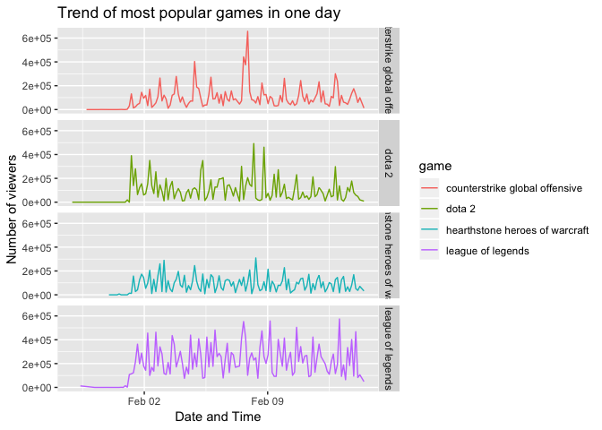

```r
library(lubridate)
library(dplyr)
library(highcharter)
library(ggplot2)
library(tm)

stream_evo = datalist %>%
  select('created_time',
         'game',
         'current_views',
         'total_views',
         'broadcaster_name',
         'followers_number',
         'language',
         'web_language',
         'broadcaster_created_time',
         'bitrate',
         'resolution') %>%
  mutate(game = tolower(game)) %>%
  mutate(game = removePunctuation(game)) %>%
  mutate(time = as.numeric(as.POSIXct(created_time,
                                      format="%Y-%m-%dT%H:%M:%SZ"),units="secs"))

stream_evo = stream_evo %>%
  mutate(game = ifelse(game=='call of duty® advanced warfare',
                       'call of duty advanced warfare',
                       game)) %>%
  mutate(game = ifelse(game=='cod advanced warfare',
                       'call of duty advanced warfare',
                       game)) %>%
  mutate(game = ifelse(game=='cs go',
                       'counterstrike global offensive',
                       game)) %>%
  mutate(game = ifelse(game=='csgo',
                       'counterstrike global offensive',
                       game)) %>%
  mutate(game = ifelse(game=='lol',
                       'league of legends',
                       game)) %>%
  mutate(game = ifelse(game=='arma 3',
                       'arma iii',
                       game)) %>%
  mutate(game = ifelse(game=='advanced warfare',
                       'call of duty advanced warfare',
                       game)) %>%
  mutate(game = ifelse(game=='dota2',
                       'dota 2',
                       game)) %>%
  mutate(game = ifelse(game=='gtav',
                       'grand theft auto v',
                       game)) %>%
  mutate(game = ifelse(game=='gta v',
                       'grand theft auto v',
                       game)) %>%
  mutate(game = ifelse(game=='gta5',
                       'grand theft auto v',
                       game)) %>%
  mutate(game = ifelse(game=='gta 5',
                       'grand theft auto v',
                       game))


stream_evo_cut = stream_evo %>% mutate(cuts = cut(time, breaks = 336)) %>%
  group_by(game) %>%
  mutate(popularity = sum(current_views)) %>%
  ungroup() %>%
  group_by(game, cuts) %>%
  summarize(popularity = mean(popularity), n = sum(current_views)) %>%
  mutate (time = as.numeric(
    sub("[^,]*,([^]]*)\\]", "\\1", cuts)),
    time = as.POSIXct(time, origin = "1970-01-01", tz = "EST")) %>%
  filter(popularity > 8000000, game != '1')

ggplot(data=stream_evo_cut, aes(x=time, y=n, colour=game)) +
  geom_line() +
  ggtitle("Trend of most popular games in one day") +
  xlab("Date and Time") +
  ylab("Number of viewers") +
  facet_grid(game~.)
```

#### One day demand evolution of most popular games by country

In this part, I want to find the most popular games demand based on countries to find out which country uses this platform the most. This finding gives us an understanding of Twitch audience distribution around the world. As you can see in the graph, the US has the most users than the other countries.

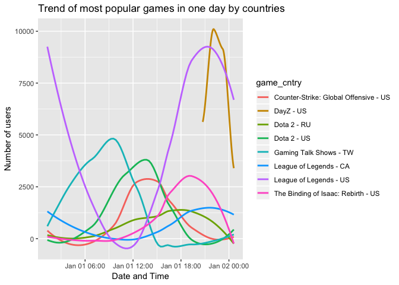

```r
stream_evo_cntry = streams %>%
  select('time','game', 'country') %>%
  mutate(time = as.numeric(as.POSIXct(time))) %>%
  mutate(cuts = cut(time, c(1420070200,
                            1420075346,
                            1420080293,
                            1420085239,
                            1420090186,
                            1420095132,
                            1420100079,
                            1420105025,
                            1420109972,
                            1420114918,
                            1420119865,
                            1420124811,
                            1420129758,
                            1420134704,
                            1420139651,
                            1420144597,
                            1420149544,
                            1420154490,
                            1420159437,
                            1420164383,
                            1420169330,
                            Inf))) %>%
  group_by(game, country, cuts) %>%
  summarize(n = n()) %>%
  mutate(popularity = sum(n), time = as.numeric(
    sub("[^,]*,([^]]*)\\]", "\\1", cuts)),
    time = as.POSIXct(time, origin = "1970-01-01", tz = "GMT")) %>%
  filter(popularity > 11000)

stream_evo_cntry$game_cntry = paste(stream_evo_cntry$game, "-", stream_evo_cntry$country)

ggplot(data=stream_evo_cntry, aes(x=time, y=n, colour=game_cntry)) + geom_smooth(se=FALSE) +
  ggtitle("Trend of most popular games in one day by countries") +
  xlab("Date and Time") +
  ylab("Number of users")
```

#### Short-term demand evolution of most popular games by languages

In this part, I try to find the most used language to stream the most popular games. This plot helps us to find the preferences of users that they prefer to show these games in which language. English was the most popular language in the most popular games, and after that, Russian is the most popular one in only Dota 2.

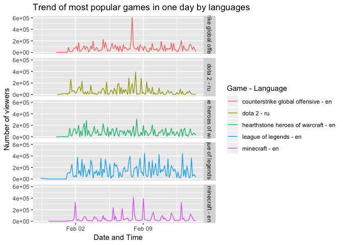

```r
stream_evo_cntry = stream_evo %>% mutate(cuts = cut(time, breaks = 336)) %>%
  group_by(game, language) %>%
  mutate(popularity = sum(current_views)) %>%
  ungroup() %>%
  group_by(game, language, cuts) %>%
  summarize(popularity = mean(popularity), n = sum(current_views)) %>%
  mutate (time = as.numeric(
    sub("[^,]*,([^]]*)\\]", "\\1", cuts)),
    time = as.POSIXct(time, origin = "1970-01-01", tz = "EST"))%>%
  filter(popularity > 5000000, game != '1')

stream_evo_cntry$game_cntry = paste(stream_evo_cntry$game, "-", stream_evo_cntry$language)

ggplot(data=stream_evo_cntry, aes(x=time, y=n, colour=game_cntry)) +
  geom_line() +
  ggtitle("Trend of most popular games in one day by languages") +
  xlab("Date and Time") +
  ylab("Number of viewers") +
  labs(color='Game - Language') +
  facet_grid(game_cntry~.)
```

#### Short-term demand evolution of Twitch platform

In this part, I want to show when users use this platform and when this platform meets its peeks. It was evident that in a 24-hour time span, you can see a sine shape of usage and that because of most people’s behaviours. People usually start to spend time on their hobbies after working time, and they go to sleep after a while. As a result, in the evening, Twitch catches the maximum users and minimum usage in the mornings.

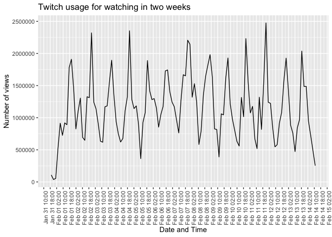

```r
library(scales)

stream_evo_twch = stream_evo %>% mutate(cuts = cut(time, breaks = 336)) %>%
  group_by(cuts) %>%
  summarize(n = sum(current_views)) %>%
  mutate (time = as.numeric(
    sub("[^,]*,([^]]*)\\]", "\\1", cuts)),
    time = as.POSIXct(time, origin = "1970-01-01", tz = "EST")) %>%
  filter(time > as_datetime("2015-02-01 00:00:00"))

ggplot(data=stream_evo_twch, aes(x=time, y=n)) +
  geom_line() +
  ggtitle("Twitch usage for watching in two weeks") +
  xlab("Date and Time") +
  ylab("Number of views") +
  scale_x_datetime(breaks = date_breaks("8 hours"), date_labels = "%b %d %H:%M") +
  theme(axis.text.x = element_text(angle = 90, hjust = 1))
```

#### One day demand evolution of Twitch platform

In the next part, I use the one day to magnify the users’ preference in choosing time to use this platform.

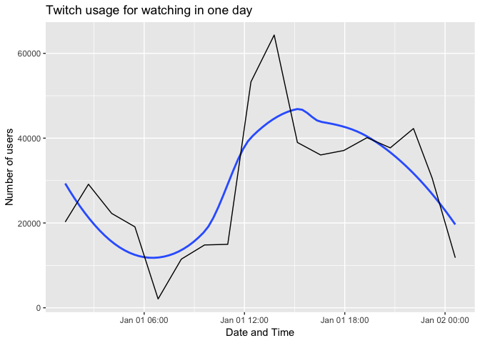

```r
stream_dem = streams %>%
  select('time') %>%
  mutate(time = as.numeric(as.POSIXct(time))) %>%
  mutate(cuts = cut(time, c(1420070200,
                            1420075346,
                            1420080293,
                            1420085239,
                            1420090186,
                            1420095132,
                            1420100079,
                            1420105025,
                            1420109972,
                            1420114918,
                            1420119865,
                            1420124811,
                            1420129758,
                            1420134704,
                            1420139651,
                            1420144597,
                            1420149544,
                            1420154490,
                            1420159437,
                            1420164383,
                            1420169330,
                            Inf))) %>%
  group_by(cuts) %>%
  summarize(n = n()) %>%
  mutate(time = as.numeric(sub("[^,]*,([^]]*)\\]", "\\1", cuts)),
    time = as.POSIXct(time, origin = "1970-01-01", tz = "GMT"))

ggplot(data=stream_dem, aes(x= time, y=n)) + geom_smooth(se=FALSE) + geom_line() +
  ggtitle("Twitch usage for watching in one day") +
  xlab("Date and Time") +
  ylab("Number of users")
```

#### Short-term demand evolution of Twitch by languages

In the next part, I illustrate the two weeks for Twitch usage by languages. As you can see in this plot, most of the countries have the same time preference because the most common languages are used in top usage countries, and those countries have very similar timezones. In the table, you can see the number of users in each language.

```r
stream_evo_twch_cntry = stream_evo %>% mutate(cuts = cut(time, breaks = 336)) %>%
  group_by(language) %>%
  mutate(popularity = sum(current_views)) %>%
  ungroup() %>%
  group_by(language, cuts) %>%
  summarize(popularity = mean(popularity), n = sum(current_views)) %>%
  mutate (time = as.numeric(
    sub("[^,]*,([^]]*)\\]", "\\1", cuts)),
    time = as.POSIXct(time, origin = "1970-01-01", tz = "EST")) %>%
  filter(time > as_datetime("2015-02-01 00:00:00")) %>%
  filter(popularity > 3000000, language != '-1')

stat_lang_twch = stream_evo_twch_cntry %>%
  ungroup() %>%
  group_by(language) %>%
  summarise(n = sum(n)) %>%
  arrange(-n)

knitr::kable(stat_lang_twch)
```

| language | n |
| --- | --- |
| en | 91896076 |
| ru | 11626858 |
| de | 7984007 |
| pt | 3531071 |
| fr | 3503320 |

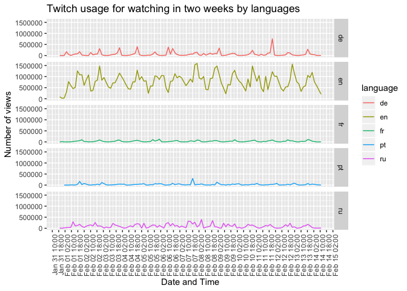

```r
ggplot(data=stream_evo_twch_cntry, aes(x=time, y= n, colour= language)) +
  geom_line() +
  ggtitle("Twitch usage for watching in two weeks by languages") +
  xlab("Date and Time") +
  ylab("Number of views") +
  scale_x_datetime(breaks = date_breaks("8 hours"), date_labels = "%b %d %H:%M") +
  theme(axis.text.x = element_text(angle = 90, hjust = 1)) +
  facet_grid(language~.)
```

#### Short-term demand evolution of Twitch by country

In this plot, I want to magnify the usage of the countries in one day. This plot can prove the previous assumption. For example, users in Taiwan are entirely in another different timezone. They oppositely use this platform.

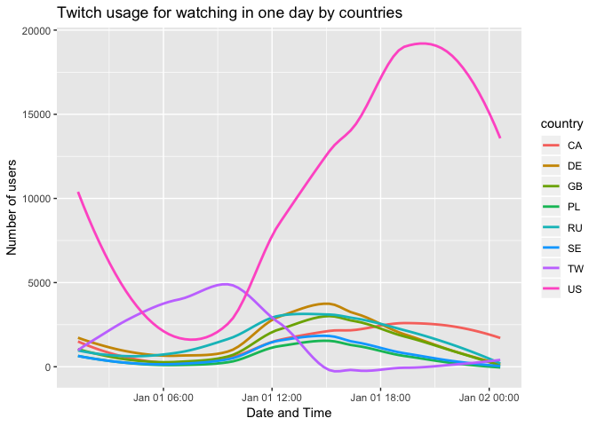

```r
stream_dem_cntry = streams %>%
  select('time', 'country') %>%
  mutate(time = as.numeric(as.POSIXct(time))) %>%
  mutate(cuts = cut(time, c(1420070200,
                            1420075346,
                            1420080293,
                            1420085239,
                            1420090186,
                            1420095132,
                            1420100079,
                            1420105025,
                            1420109972,
                            1420114918,
                            1420119865,
                            1420124811,
                            1420129758,
                            1420134704,
                            1420139651,
                            1420144597,
                            1420149544,
                            1420154490,
                            1420159437,
                            1420164383,
                            1420169330,
                            Inf))) %>%
  group_by(country, cuts) %>%
  summarize(n = n()) %>%
  mutate(dem_c = sum(n), time = as.numeric(sub("[^,]*,([^]]*)\\]", "\\1", cuts)),
    time = as.POSIXct(time, origin = "1970-01-01", tz = "GMT")) %>%
  filter(dem_c > 10000)

stream_dem_cntry = na.omit(stream_dem_cntry)

ggplot(data=stream_dem_cntry, aes(x= time, y=n, colour = country)) + geom_smooth(se=FALSE)+
  ggtitle("Twitch usage for watching in one day by countries") +
  xlab("Date and Time") +
  ylab("Number of users")
```

#### Streamers’ followers number evolution

##### Low-Tier

In this plot, it is clearly visible that no one lost followers, and the number of new followers is in O(#followers).

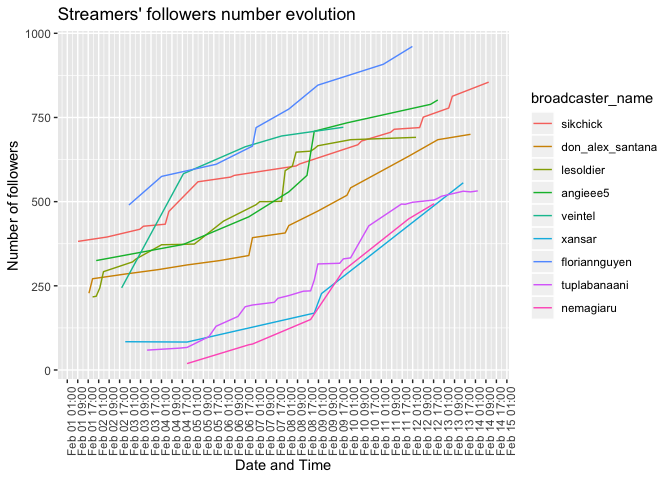

```r
flwr_evo = stream_evo %>%
  filter(followers_number > 0) %>%
  group_by(broadcaster_name) %>%
  mutate(max_followers = max(followers_number)) %>%
  ungroup() %>%
  mutate(cuts = cut(time, breaks = 336)) %>%
  group_by(broadcaster_name, cuts) %>%
  summarise(followers_mean = max(followers_number), max_followers = mean(max_followers)) %>%
  mutate (time = as.numeric(
    sub("[^,]*,([^]]*)\\]", "\\1", cuts)),
    time = as.POSIXct(time, origin = "1970-01-01", tz = "EST"),
    num_time = as.numeric(as.POSIXct(time,
                                      format="%Y-%m-%d %H:%M:%S"),units="secs"))

low_tier = flwr_evo %>%
  filter(100<max_followers & max_followers<1000) %>%
  ungroup() %>%
  group_by(broadcaster_name) %>%
  mutate(diff = max(followers_mean) - min(followers_mean)) %>%
  filter(diff > 470, diff < 480)

ggplot(data=low_tier, aes(x=time, y= followers_mean, colour= broadcaster_name)) +
  geom_line() +
  ggtitle("Streamers' followers number evolution") +
  xlab("Date and Time") +
  ylab("Number of followers") +
  scale_x_datetime(breaks = date_breaks("8 hours"), date_labels = "%b %d %H:%M") +
  theme(axis.text.x = element_text(angle = 90, hjust = 1))
```

##### Mid-Tier

In this plot, it is visible that no one lost followers, and the number of new followers is in O(#followers) too. Interestingly, lots of these streamers have the same pace in gaining followers.

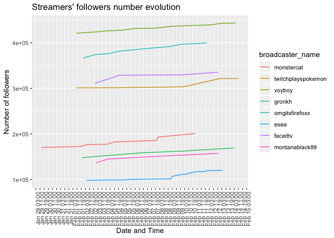

```r
mid_tier = flwr_evo %>%
  filter(100000<max_followers & max_followers<500000) %>%
  ungroup() %>%
  group_by(broadcaster_name) %>%
  mutate(diff = max(followers_mean) - min(followers_mean)) %>%
  filter(diff > 20000, diff < 40000)

ggplot(data=mid_tier, aes(x=time, y= followers_mean, colour= broadcaster_name)) +
  geom_line() +
  ggtitle("Streamers' followers number evolution") +
  xlab("Date and Time") +
  ylab("Number of followers") +
  scale_x_datetime(breaks = date_breaks("8 hours"), date_labels = "%b %d %H:%M") +
  theme(axis.text.x = element_text(angle = 90, hjust = 1))
```

##### High Tier

In this plot, it is visible that no one lost followers, and the number of new followers is in O(#followers) too. Interestingly, lots of these streamers have the same pace in gaining followers, and if you consider the number of new followers for every streamer in this tier, this function would be roughly linear.

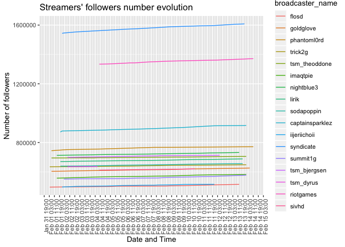

```r
 high_tier = flwr_evo %>%
  filter(500000<max_followers & max_followers<10000000) %>%
  ungroup() %>%
  group_by(broadcaster_name) %>%
  mutate(diff = max(followers_mean) - min(followers_mean))

ggplot(data=high_tier, aes(x=time, y= followers_mean, colour= broadcaster_name)) +
  geom_line() +
  ggtitle("Streamers' followers number evolution") +
  xlab("Date and Time") +
  ylab("Number of followers") +
  scale_x_datetime(breaks = date_breaks("8 hours"), date_labels = "%b %d %H:%M") +
  theme(axis.text.x = element_text(angle = 90, hjust = 1))
```

### Hypotesis Tests.

In this section, I will try to prove some hypotheses by some statistical tests.

#### Anonymous viewers vs. subscribers

In this part, I test that if you have more followers, you will get more views. A correlation test can prove it, the result shows that they are highly correlated to each other.

```r
anms_scbr = streams %>%
  group_by(subscriber) %>%
  summarize(n = n()) %>%
  na.omit() %>%
  mutate(n = n*100/sum(n))

anms_scbr %>% hchart(type='pie', hcaes(x=subscriber, y=n), name='%') %>% hc_xAxis(title=list(text='Is the user subscried to streamer?'))
```

[interactive chart not shown]

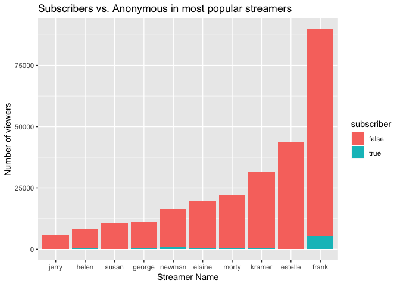

```r
anms_scbr_hist = streams %>%
  group_by(channel, subscriber) %>%
  na.omit() %>%
  summarize(total = n()) %>%
  mutate(t_tf = sum(total))

ggplot(anms_scbr_hist, aes(x=reorder(channel, total), y=total, fill=subscriber)) +
  geom_col() +
  ggtitle("Subscribers vs. Anonymous in most popular streamers") +
  xlab("Streamer Name") +
  ylab("Number of viewers")
```

```r
anms_scbr_hist_t = anms_scbr_hist %>%
  filter(subscriber == 'true')
cor.test(anms_scbr_hist_t$total, anms_scbr_hist_t$t_tf)
```

```
    Pearson's product-moment correlation

data:  anms_scbr_hist_t$total and anms_scbr_hist_t$t_tf
t = 4.9176, df = 8, p-value = 0.001168
alternative hypothesis: true correlation is not equal to 0
95 percent confidence interval:
 0.5222599 0.9680954
sample estimates:
      cor
0.8668434
```

#### The linear relation between the number of followers and time in High-Tier

In this part, I test that is there any linear relationships exist between followers gain and time. The result shows that followers gain is completely linear.

```r
tsm_theoddone_data = high_tier %>%
  filter(broadcaster_name == 'tsm_theoddone')

cor.test(tsm_theoddone_data$followers_mean, tsm_theoddone_data$num_time)
```

```
    Pearson's product-moment correlation

data:  tsm_theoddone_data$followers_mean and tsm_theoddone_data$num_time
t = 32.62, df = 20, p-value < 2.2e-16
alternative hypothesis: true correlation is not equal to 0
95 percent confidence interval:
 0.9773742 0.9962190
sample estimates:
      cor
0.9907323
```

#### Streamers’ membership lenght vs. number of followers

```r
stream_evo_age = stream_evo %>%
  group_by(broadcaster_name) %>%
  mutate(max_flwr = max(followers_number),
         created_time_num = as.numeric(as.POSIXct(broadcaster_created_time,
                                                  format="%Y-%m-%dT%H:%M:%SZ"),
                                       units="secs")) %>%
  summarise(max_flwr = mean(max_flwr), created_time_num = mean(created_time_num)) %>%
  filter(max_flwr > 0) %>%
  mutate(created_time_num_norm = created_time_num - min(created_time_num) + 1)

cor.test(stream_evo_age$max_flwr, stream_evo_age$created_time_num_norm)
```

```
    Pearson's product-moment correlation

data:  stream_evo_age$max_flwr and stream_evo_age$created_time_num_norm
t = -44.79, df = 467620, p-value < 2.2e-16
alternative hypothesis: true correlation is not equal to 0
95 percent confidence interval:
 -0.06821299 -0.06250513
sample estimates:
       cor
-0.0653596
```

#### Device Usages.

In this plot, I investigate the devices that users usually use to reach this platform. As you can see from the chart, web-browsers are the most popular ones.

```r
stream_device = streams %>%
  group_by(player) %>%
  summarize(n = n()) %>%
  mutate(total = sum(n), n = n*100/total)

stream_device %>% hchart(type='pie', hcaes(x=player, y=n), name='%')
```

[interactive chart not shown]

### Conclusion.

In this project, I try to investigate every possible aspect of Twitch to find how the trends change in a short period. I try to examine games and streamers to see how they evolve and how they use this platform from every corner of this world. Then I try to prove some of my claims with hypothesis tests. Because of my limited resources, I couldn’t use all the bigger dataset, and I only use 2 weeks of this dataset and 24 samples per day, but It can be done by the whole dataset and find some reacher information in more extended periods, and I consider this as future work.